# M_Pox Analysis

Fesobi Oreofeoluwa

2025-02-27

# M_Pox Data Analysis

This is an analysis carried out on an M-Pox Data-set from <htpps://catalog.ourworldindata.org>:

## Data Set-up

```r
M_Pox <- read.csv("C:/Users/USER/Downloads/monkeypox.csv")
```

Date (character) variable is converted to a date data type,

```r
Dates<- as.Date(M_Pox$date)
M_Pox <- mutate(M_Pox,Date = Dates)
```

```r
M_Pox[is.na(M_Pox)] <- 0
```

### Data Filtering

For better data exploration the data set has been Grouped into locations of the world(Continents)

```r
Afri <- M_Pox%>%
  filter(location %in% c("Africa", "Benin","Cameroon","Central African Republic",
                         "Congo","Cote d'Ivoire","Democratic Republic of Congo",
                         'Egypt','Ghana','Guinea','Kenya','Liberia','Morocco',
                         'Mozambique','Nigeria','Rwanda','South Africa','Sudan','Uganda',
                         'Zambia','Zimbabwe'))
head(Afri)
```

```
##   location       date iso_code total_cases total_deaths new_cases new_deaths
## 1   Africa 2022-05-01 OWID_AFR          42            2         2          0
## 2   Africa 2022-05-02 OWID_AFR          42            2         0          0
## 3   Africa 2022-05-03 OWID_AFR          42            2         0          0
## 4   Africa 2022-05-04 OWID_AFR          42            2         0          0
## 5   Africa 2022-05-05 OWID_AFR          42            2         0          0
## 6   Africa 2022-05-06 OWID_AFR          42            2         0          0
##   new_cases_smoothed new_deaths_smoothed new_cases_per_million
## 1               0.29                   0                 0.001
## 2               0.29                   0                 0.000
## 3               0.29                   0                 0.000
## 4               0.29                   0                 0.000
## 5               0.29                   0                 0.000
## 6               0.29                   0                 0.000
##   total_cases_per_million new_cases_smoothed_per_million new_deaths_per_million
```

[output cut: 20 more lines]

```r
Euro <- M_Pox%>%
  filter(location %in% c("Europe", "Andorra","Austria","Belgium","Bosnia and Herzegovina",
                         "Bulgaria","Croatia","Cyprus","Czechia","Denmark",'Estonia'
                         ,'Europe','France','Georgia','Germany','Gibraltar','Greece',
                         'Greenland','Hungary','Iceland','Ireland','Italy','Latvia',
                         'Lithuania','Luxembourg','Malta','Martinique','Moldova',
                         'Monaco','Montenegro','Netherlands','Norway','Poland',
                         'Portugal','Romania','Russia','Saint Martin (French part)',
                         'San Marino','Serbia','Slovakia','Slovenia','Spain','Sweden',
                         'Switzerland','Turkey','Ukraine','United Kingdom'))
head(Euro)
```

```
##   location       date iso_code total_cases total_deaths new_cases new_deaths
## 1  Andorra 2022-07-25      AND           2            0         2          0
## 2  Andorra 2022-07-26      AND           3            0         1          0
## 3  Andorra 2022-07-27      AND           3            0         0          0
## 4  Andorra 2022-07-28      AND           3            0         0          0
## 5  Andorra 2022-07-29      AND           3            0         0          0
## 6  Andorra 2022-07-30      AND           3            0         0          0
##   new_cases_smoothed new_deaths_smoothed new_cases_per_million
## 1               0.29                   0                25.044
## 2               0.43                   0                12.522
## 3               0.43                   0                 0.000
## 4               0.43                   0                 0.000
## 5               0.43                   0                 0.000
## 6               0.43                   0                 0.000
##   total_cases_per_million new_cases_smoothed_per_million new_deaths_per_million
```

[output cut: 20 more lines]

```r
Asia <- M_Pox%>%
  filter(location %in% c("Asia", "Bahrain","Cambodia","China",'India','Indonesia',
                         'Iran','Israel','Japan','Jordan','Laos','Lebanon','Malaysia',
                         'Nepal','Oman','Pakistan','Philippines','Qatar','Saudi Arabia',
                         'Singapore','South Korea','Sri Lanka','Thailand','United Arab Emirates',
                         'Vietnam'))
head(Asia)
```

```
##   location       date iso_code total_cases total_deaths new_cases new_deaths
## 1     Asia 2022-05-01 OWID_ASI           0            0         0          0
## 2     Asia 2022-05-02 OWID_ASI           0            0         0          0
## 3     Asia 2022-05-03 OWID_ASI           0            0         0          0
## 4     Asia 2022-05-04 OWID_ASI           0            0         0          0
## 5     Asia 2022-05-05 OWID_ASI           0            0         0          0
## 6     Asia 2022-05-06 OWID_ASI           0            0         0          0
##   new_cases_smoothed new_deaths_smoothed new_cases_per_million
## 1                  0                   0                     0
## 2                  0                   0                     0
## 3                  0                   0                     0
## 4                  0                   0                     0
## 5                  0                   0                     0
## 6                  0                   0                     0
##   total_cases_per_million new_cases_smoothed_per_million new_deaths_per_million
```

[output cut: 20 more lines]

```r
Ocea <- M_Pox%>%
  filter(location %in% c("Oceania", "Australia",'Guam','New Caledonia','New Zealand'))
head(Ocea)
```

```
##    location       date iso_code total_cases total_deaths new_cases new_deaths
## 1 Australia 2022-05-20      AUS           2            0         2          0
## 2 Australia 2022-05-21      AUS           2            0         0          0
## 3 Australia 2022-05-22      AUS           2            0         0          0
## 4 Australia 2022-05-23      AUS           2            0         0          0
## 5 Australia 2022-05-24      AUS           2            0         0          0
## 6 Australia 2022-05-25      AUS           2            0         0          0
##   new_cases_smoothed new_deaths_smoothed new_cases_per_million
## 1               0.29                   0                 0.076
## 2               0.29                   0                 0.000
## 3               0.29                   0                 0.000
## 4               0.29                   0                 0.000
## 5               0.29                   0                 0.000
## 6               0.29                   0                 0.000
##   total_cases_per_million new_cases_smoothed_per_million new_deaths_per_million
```

[output cut: 20 more lines]

```r
Nt_Ame <- M_Pox%>%
  filter(location %in% c("North America","Canada","Costa Rica","Cuba",
                         'Dominican Republic','El Salvador','Guadeloupe','Guatemala',
                         'Honduras','Jamaica','Mexico','Panama','Trinidad and Tobago',
                         'United States'))
head(Nt_Ame)
```

```
##   location       date iso_code total_cases total_deaths new_cases new_deaths
## 1   Canada 2022-05-01      CAN           3            0         0          0
## 2   Canada 2022-05-02      CAN           3            0         0          0
## 3   Canada 2022-05-03      CAN          15            0        12          0
## 4   Canada 2022-05-04      CAN          15            0         0          0
## 5   Canada 2022-05-05      CAN          15            0         0          0
## 6   Canada 2022-05-06      CAN          15            0         0          0
##   new_cases_smoothed new_deaths_smoothed new_cases_per_million
## 1               0.43                   0                 0.000
## 2               0.43                   0                 0.000
## 3               1.71                   0                 0.312
## 4               1.71                   0                 0.000
## 5               1.71                   0                 0.000
## 6               1.71                   0                 0.000
##   total_cases_per_million new_cases_smoothed_per_million new_deaths_per_million
```

[output cut: 20 more lines]

```r
St_Ame <- M_Pox%>%
  filter(location %in% c("South America", "Argentina", "Bolivia","Brazil","Chile",
                         "Colombia","Curacao",'Ecuador','Guyana','Paraguay','Peru',
                         'Uruguay','Venezuela'))
head(St_Ame)
```

```
##    location       date iso_code total_cases total_deaths new_cases new_deaths
## 1 Argentina 2022-05-24      ARG           2            0         2          0
## 2 Argentina 2022-05-25      ARG           2            0         0          0
## 3 Argentina 2022-05-26      ARG           2            0         0          0
## 4 Argentina 2022-05-27      ARG           2            0         0          0
## 5 Argentina 2022-05-28      ARG           2            0         0          0
## 6 Argentina 2022-05-29      ARG           2            0         0          0
##   new_cases_smoothed new_deaths_smoothed new_cases_per_million
## 1               0.29                   0                 0.044
## 2               0.29                   0                 0.000
## 3               0.29                   0                 0.000
## 4               0.29                   0                 0.000
## 5               0.29                   0                 0.000
## 6               0.29                   0                 0.000
##   total_cases_per_million new_cases_smoothed_per_million new_deaths_per_million
```

[output cut: 20 more lines]

```r
Isl <- M_Pox%>%
  filter(location %in% c("Aruba", "Bahamas","Barbados","Bermuda","Burundi"))
head(Isl)
```

```
##   location       date iso_code total_cases total_deaths new_cases new_deaths
## 1    Aruba 2022-08-23      ABW           1            0         1          0
## 2    Aruba 2022-08-24      ABW           1            0         0          0
## 3    Aruba 2022-08-25      ABW           1            0         0          0
## 4    Aruba 2022-08-26      ABW           1            0         0          0
## 5    Aruba 2022-08-27      ABW           1            0         0          0
## 6    Aruba 2022-08-28      ABW           1            0         0          0
##   new_cases_smoothed new_deaths_smoothed new_cases_per_million
## 1               0.14                   0                 9.396
## 2               0.14                   0                 0.000
## 3               0.14                   0                 0.000
## 4               0.14                   0                 0.000
## 5               0.14                   0                 0.000
## 6               0.14                   0                 0.000
##   total_cases_per_million new_cases_smoothed_per_million new_deaths_per_million
```

[output cut: 20 more lines]

```r
Un_Spe <- M_Pox%>%
  filter(location %in% c("World"))
head(Un_Spe)
```

```
##   location       date iso_code total_cases total_deaths new_cases new_deaths
## 1    World 2022-05-01                   45            2         2          0
## 2    World 2022-05-02                   45            2         0          0
## 3    World 2022-05-03                   57            2        12          0
## 4    World 2022-05-04                   57            2         0          0
## 5    World 2022-05-05                   57            2         0          0
## 6    World 2022-05-06                   57            2         0          0
##   new_cases_smoothed new_deaths_smoothed new_cases_per_million
## 1               0.71                   0                 0.000
## 2               0.71                   0                 0.000
## 3               2.00                   0                 0.002
## 4               2.00                   0                 0.000
## 5               2.00                   0                 0.000
## 6               2.00                   0                 0.000
##   total_cases_per_million new_cases_smoothed_per_million new_deaths_per_million
```

[output cut: 20 more lines]

### Death Rate

Death rate for each observation is calculated Formula= Total Death / Total Cases x 100

```r
Death_R <-mutate(M_Pox,death_rate = M_Pox$total_deaths/M_Pox$total_cases*100)
Afri<- mutate(Afri,death_rate = Afri$total_deaths/Afri$total_cases*100)
Asia<- mutate(Asia,death_rate = Asia$total_deaths/Asia$total_cases*100)
Euro<- mutate(Euro,death_rate = Euro$total_deaths/Euro$total_cases*100)
Isl<- mutate(Isl,death_rate = Isl$total_deaths/Isl$total_cases*100)
Nt_Ame<- mutate(Nt_Ame,death_rate = Nt_Ame$total_deaths/Nt_Ame$total_cases*100)
Ocea<- mutate(Ocea,death_rate = Ocea$total_deaths/Ocea$total_cases*100)
St_Ame<- mutate(St_Ame,death_rate = St_Ame$total_deaths/St_Ame$total_cases*100)
Un_Spe<- mutate(Un_Spe,death_rate = Un_Spe$total_deaths/Un_Spe$total_cases*100)

MPox_Death_Rate <- Death_R

head(MPox_Death_Rate)
```

```
##   location       date iso_code total_cases total_deaths new_cases new_deaths
## 1   Africa 2022-05-01 OWID_AFR          42            2         2          0
## 2   Africa 2022-05-02 OWID_AFR          42            2         0          0
## 3   Africa 2022-05-03 OWID_AFR          42            2         0          0
## 4   Africa 2022-05-04 OWID_AFR          42            2         0          0
## 5   Africa 2022-05-05 OWID_AFR          42            2         0          0
## 6   Africa 2022-05-06 OWID_AFR          42            2         0          0
##   new_cases_smoothed new_deaths_smoothed new_cases_per_million
## 1               0.29                   0                 0.001
## 2               0.29                   0                 0.000
## 3               0.29                   0                 0.000
## 4               0.29                   0                 0.000
## 5               0.29                   0                 0.000
## 6               0.29                   0                 0.000
##   total_cases_per_million new_cases_smoothed_per_million new_deaths_per_million
```

[output cut: 20 more lines]

### Insightful Data Grouping

```r
# Average Total Cases
Afri_TC <- mean(Afri$total_cases)
Asia_TC <- mean(Asia$total_cases)
Euro_TC <- mean(Euro$total_cases)
Isl_TC <- mean(Isl$total_cases)
Nt_Ame_TC <- mean(Nt_Ame$total_cases)
Ocea_TC <- mean(Ocea$total_cases)
St_Ame_TC <- mean(St_Ame$total_cases)
Un_Spe_TC <- mean(Un_Spe$total_cases)
Total_Cases <- c(Afri_TC,Euro_TC,Asia_TC,Isl_TC,Ocea_TC,Nt_Ame_TC,St_Ame_TC,Un_Spe_TC)
```

```r
# Average Total Death
Afri_td <- mean(Afri$total_deaths )
Asia_td <- mean(Asia$total_deaths )
Euro_td <- mean(Euro$total_deaths )
Isl_td <- mean(Isl$total_deaths )
Nt_Ame_td <- mean(Nt_Ame$total_deaths )
Ocea_td <- mean(Ocea$total_deaths )
St_Ame_td <- mean(St_Ame$total_deaths )
Un_Spe_td <- mean(Un_Spe$total_deaths )
Total_Death <- c(Afri_td,Asia_td,Euro_td,Isl_td,Nt_Ame_td,Ocea_td,St_Ame_td,Un_Spe_td)
```

```r
# Average Suspected cases(Undocumented)
Afri_sc <- mean(Afri$suspected_cases_cumulative )
Asia_sc <- mean(Asia$suspected_cases_cumulative )
Euro_sc <- mean(Euro$suspected_cases_cumulative )
Isl_sc <- mean(Isl$suspected_cases_cumulative )
Nt_Ame_sc <- mean(Nt_Ame$suspected_cases_cumulative )
Ocea_sc <- mean(Ocea$suspected_cases_cumulative )
St_Ame_sc <- mean(St_Ame$suspected_cases_cumulative )
Un_Spe_sc <- mean(Un_Spe$suspected_cases_cumulative )

Suspected_Cases <- c(Afri_sc,Asia_sc,Euro_sc,Isl_sc,Nt_Ame_sc,Ocea_sc,St_Ame_sc,Un_Spe_sc)
```

```r
# Average Death rate
Afri_dr <- mean(Afri$death_rate, na.rm = TRUE )
Asia_dr <- mean(Asia$death_rate, na.rm = TRUE )
Euro_dr <- mean(Euro$death_rate, na.rm = TRUE )
Isl_dr <- mean(Isl$death_rate, na.rm = TRUE )
Nt_Ame_dr <- mean(Nt_Ame$death_rate, na.rm = TRUE )
Ocea_dr <- mean(Ocea$death_rate, na.rm = TRUE )
St_Ame_dr <- mean(St_Ame$death_rate, na.rm = TRUE )
Un_Spe_dr <- mean(Un_Spe$death_rate, na.rm = TRUE )

Death_Rates <- c(Afri_dr,Asia_dr,Euro_dr,Isl_dr,Nt_Ame_dr,Ocea_dr,St_Ame_dr,Un_Spe_dr)
```

```r
# Grouping of Data
M_Stat<- cbind(Death_Rates,Suspected_Cases,Total_Cases,Total_Death)
M_Stat<- data.frame(M_Stat)
M_Stat$Regions <- c("Afri","Asia","Euro","Isl","Nt_Ame","Ocea","St_Ame","Un_Spe")
M_Stat
```

[output not shown]

## Plots

Graphical representation of Data visual analysis

### Grouped Statistics

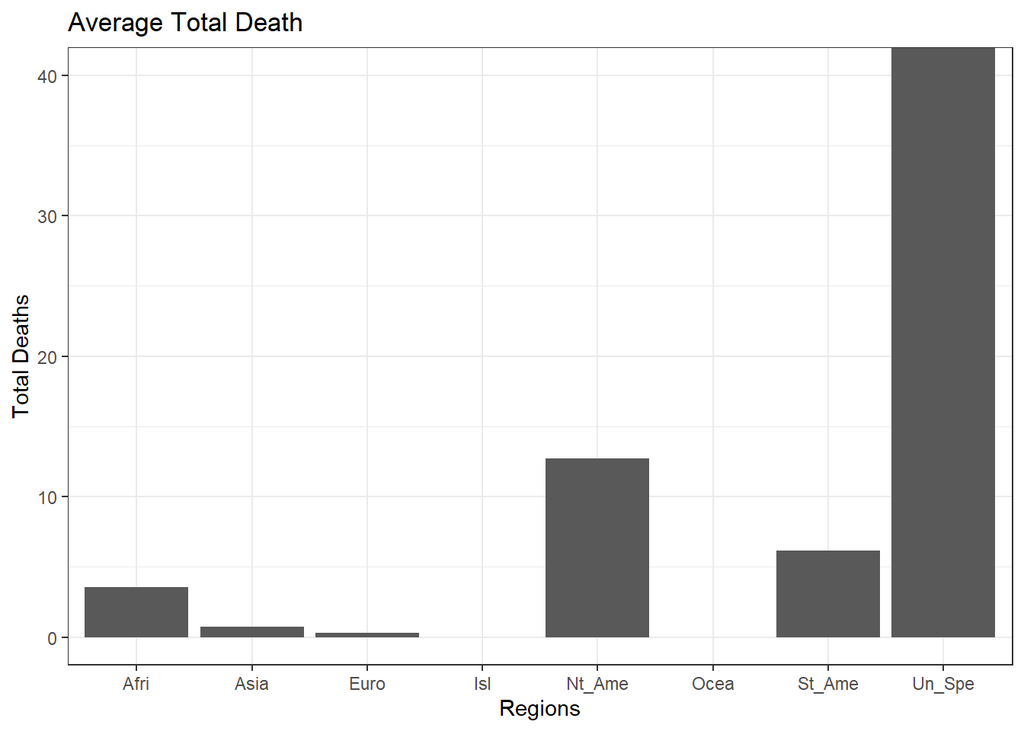

[figure not shown]

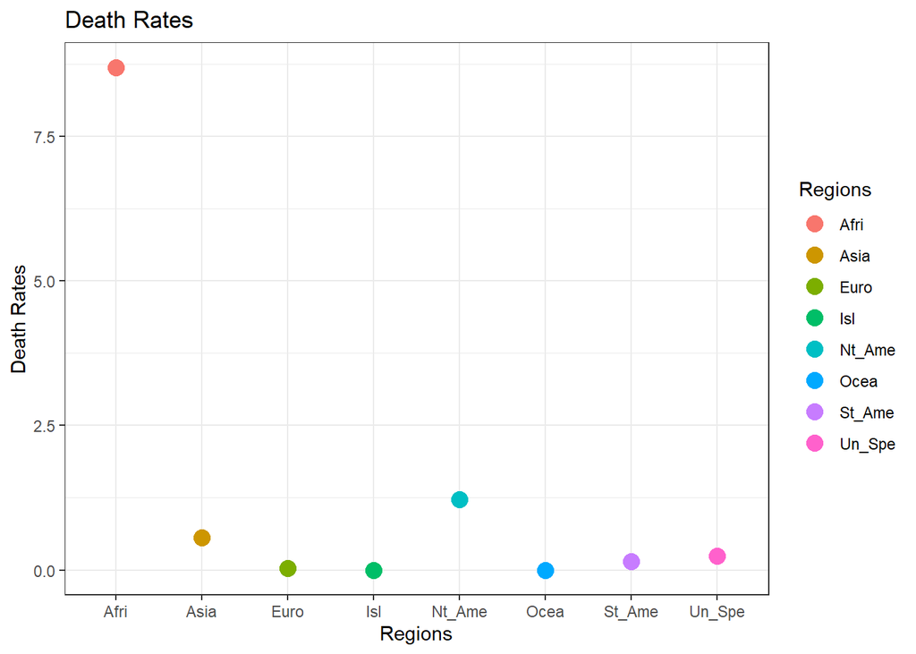

### Africa

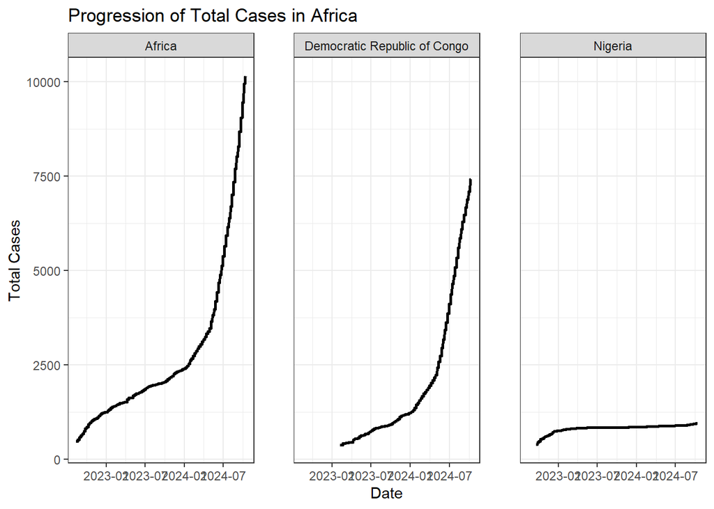

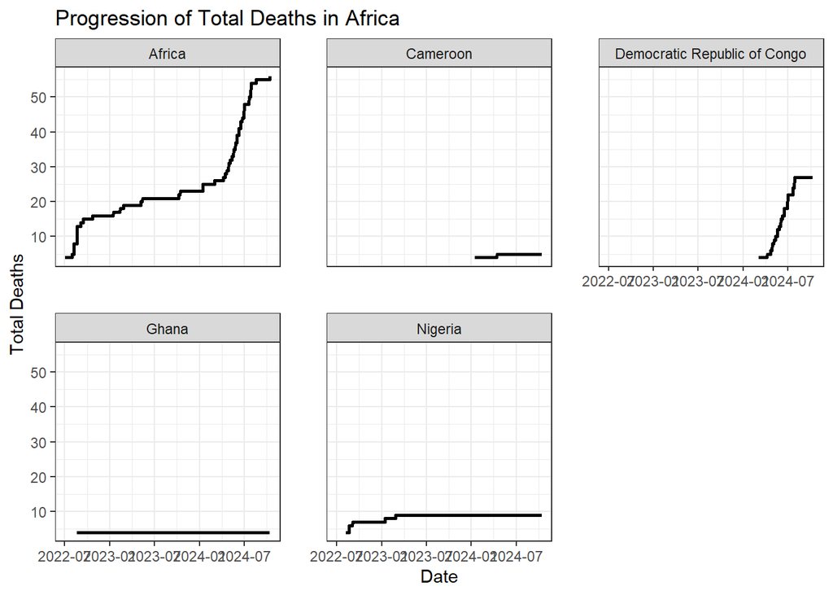

[output not shown]

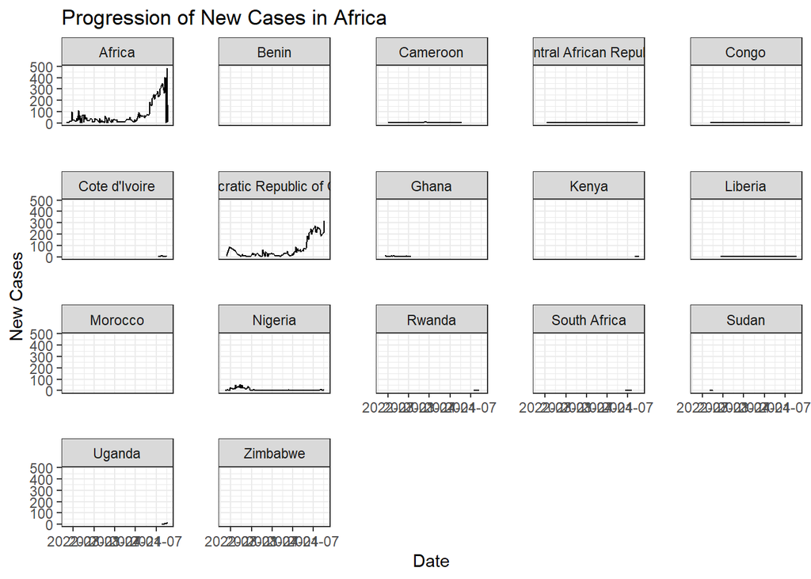

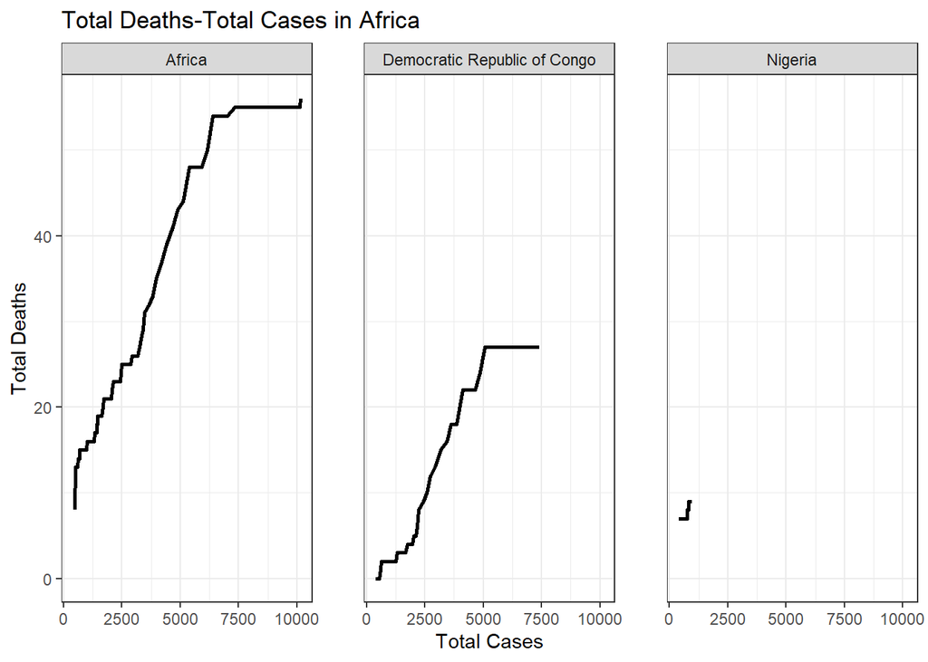

#### Summary

The Democratic Republic of Congo can be identified as the most badly affected Country in the African Region.

### Europe

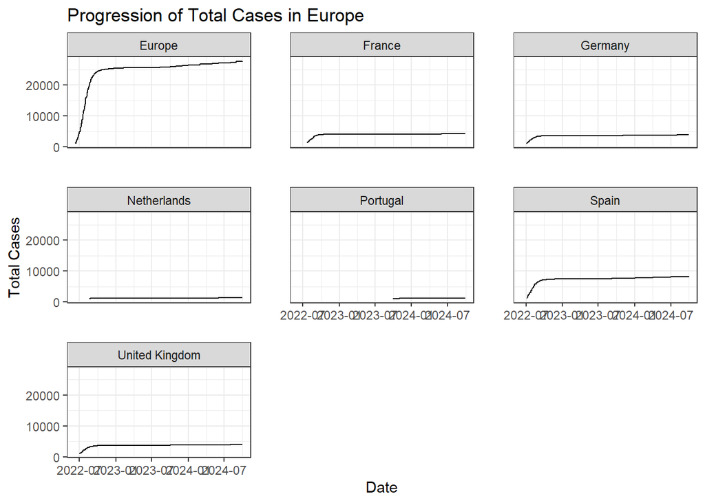

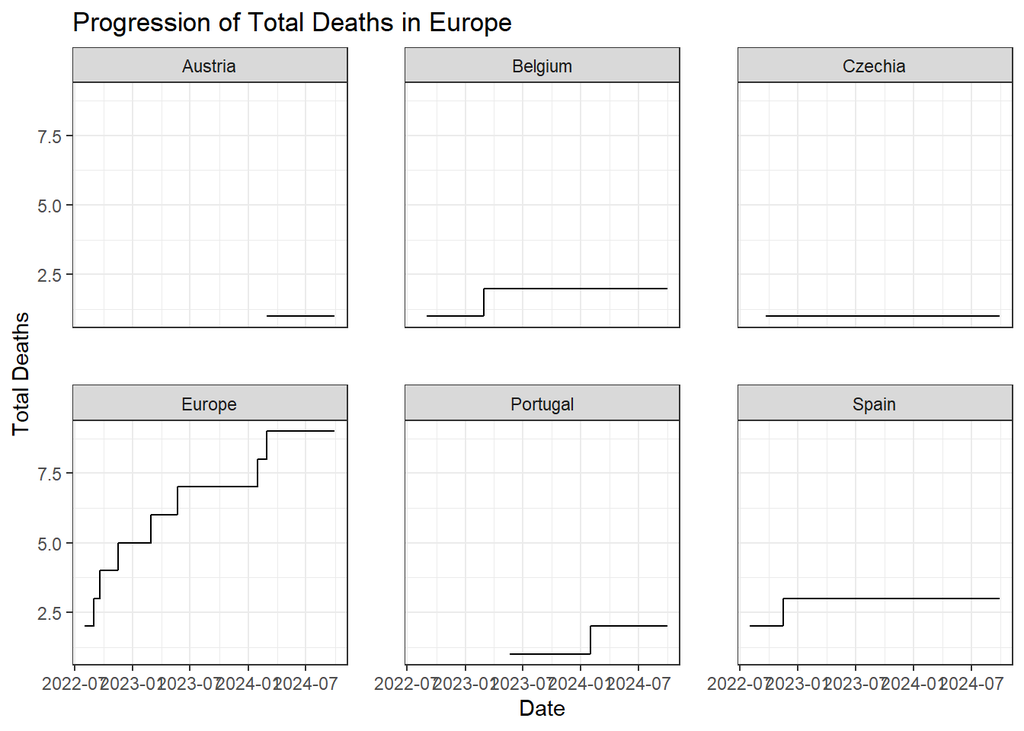

[output not shown]

[figure not shown]

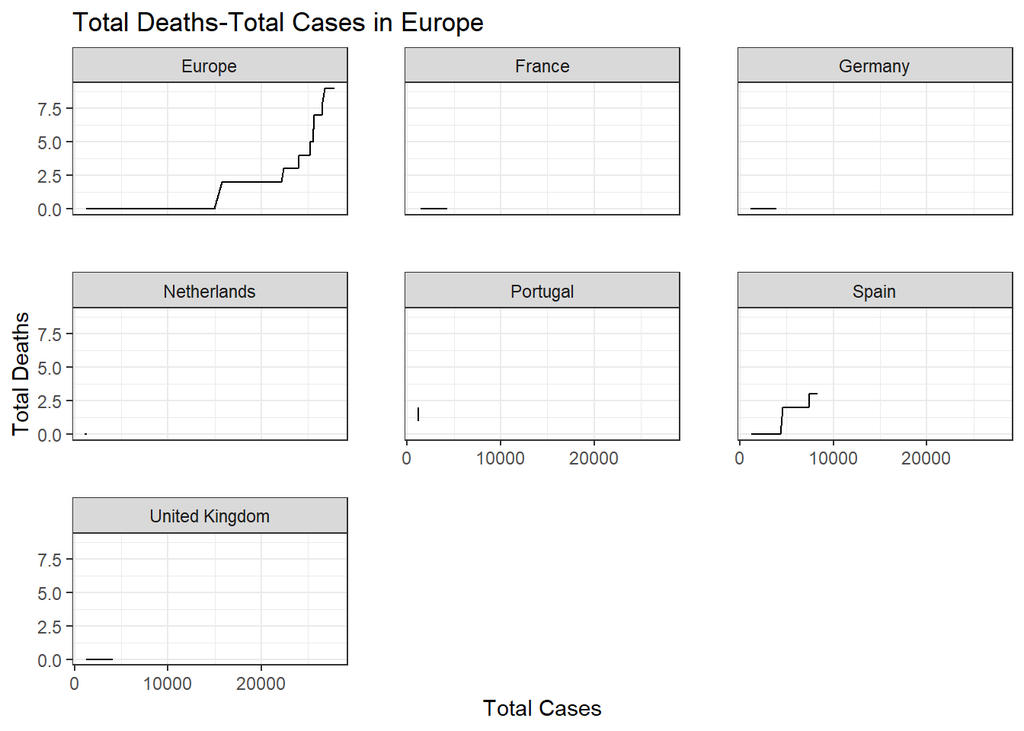

#### Summary

Different Countries where affected including; Spain, Belgium , United Kingdom and so on, with no single country taking a massive brunt of the Disease.

### Asia

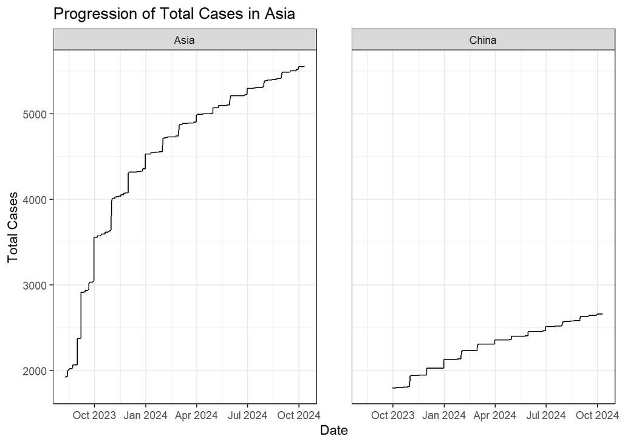

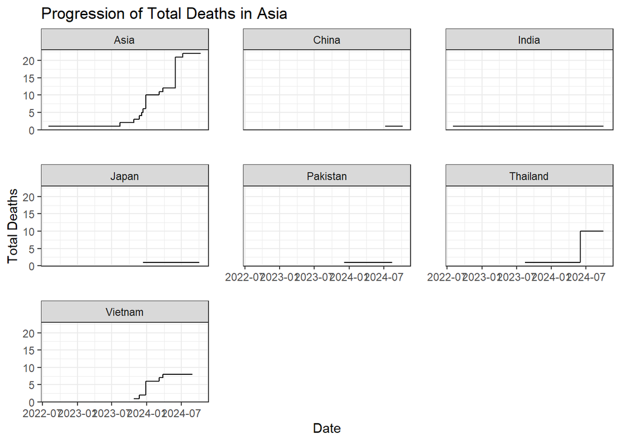

[output not shown]

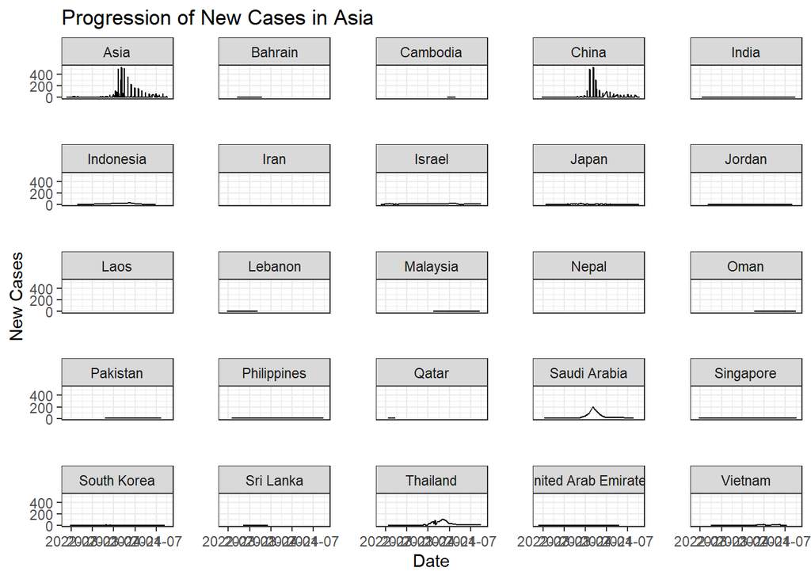

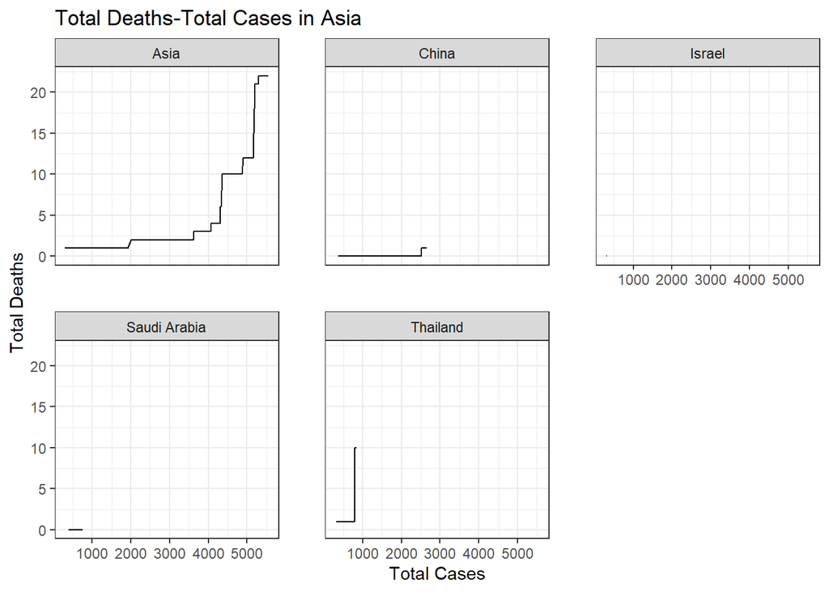

#### Summary

China appears to be the most infected Country with the largest total cases, but seeming to have learnt from the Covid-19 Pandemic, this appears to have been managed properly.

### Island Nations

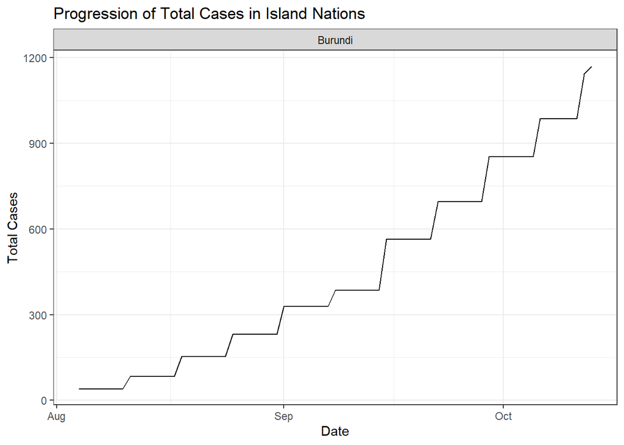

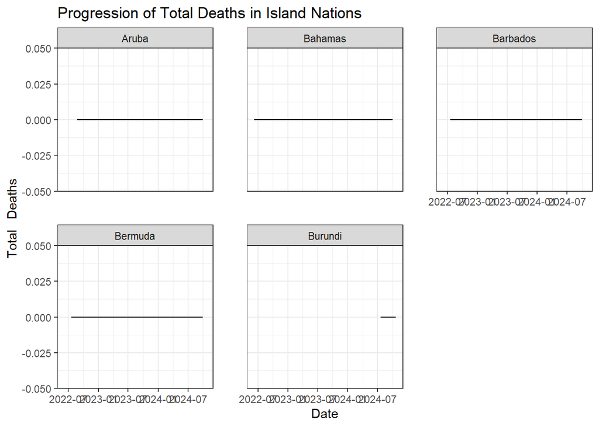

```
## `geom_line()`: Each group consists of only one observation.
## ℹ Do you need to adjust the group aesthetic?
## `geom_line()`: Each group consists of only one observation.
## ℹ Do you need to adjust the group aesthetic?
```

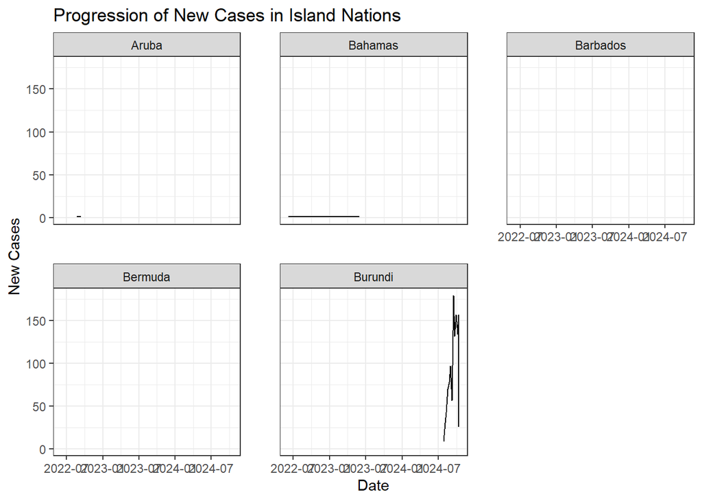

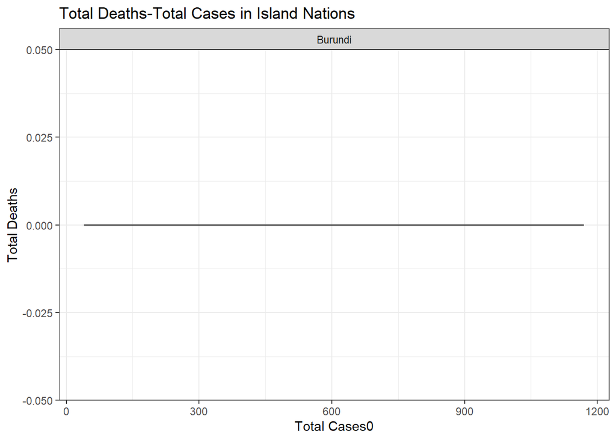

#### Summary

The Island Countries despite being infected, recorded no death.

### Oceania

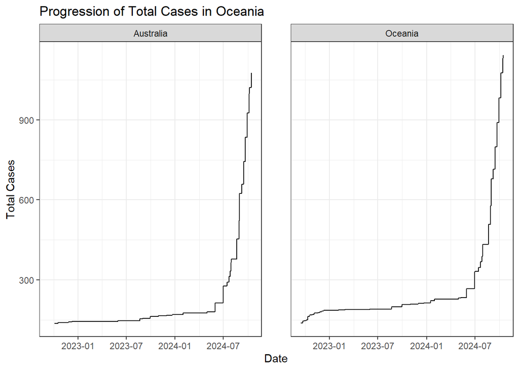

[output not shown]

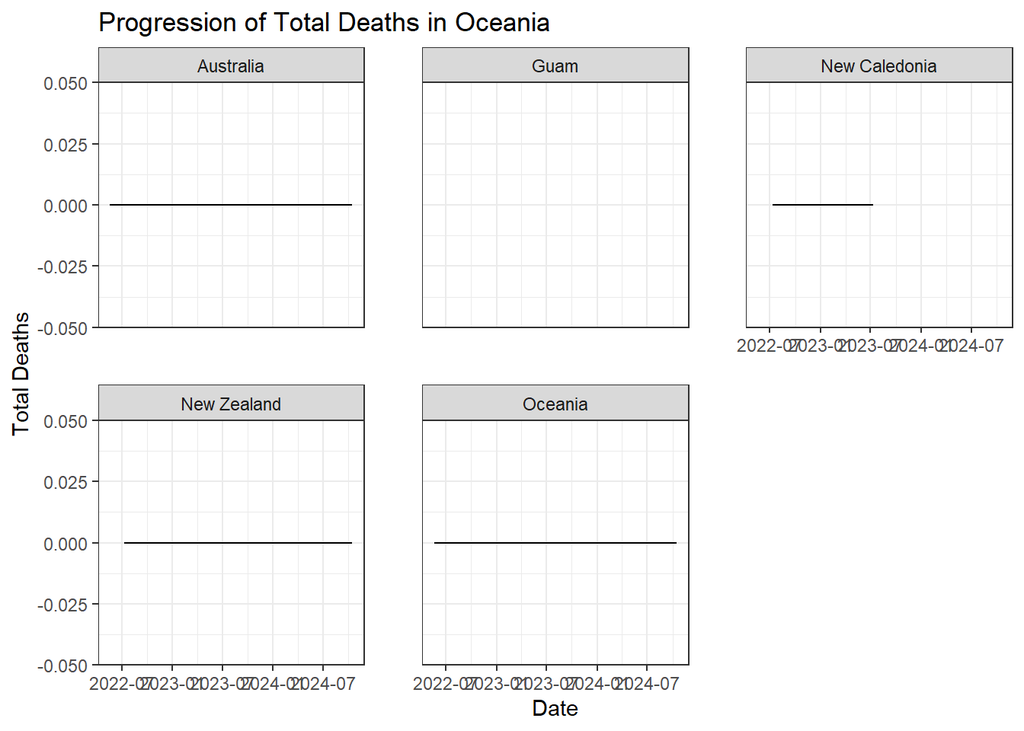

[output not shown]

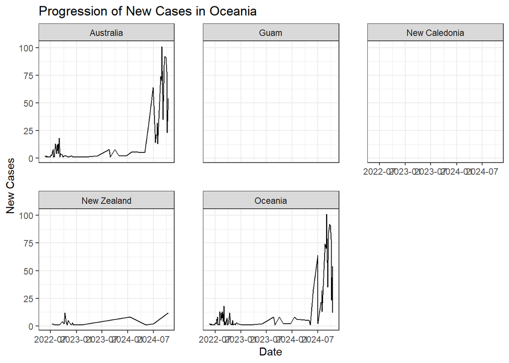

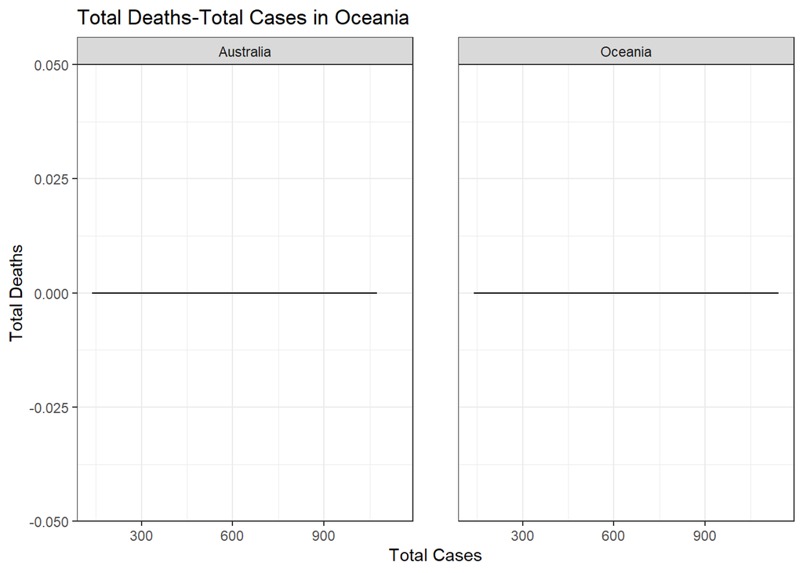

#### Summary

Similar to the Island Nations, there was a surge in recorded cases but no death was recorded.

### North_America

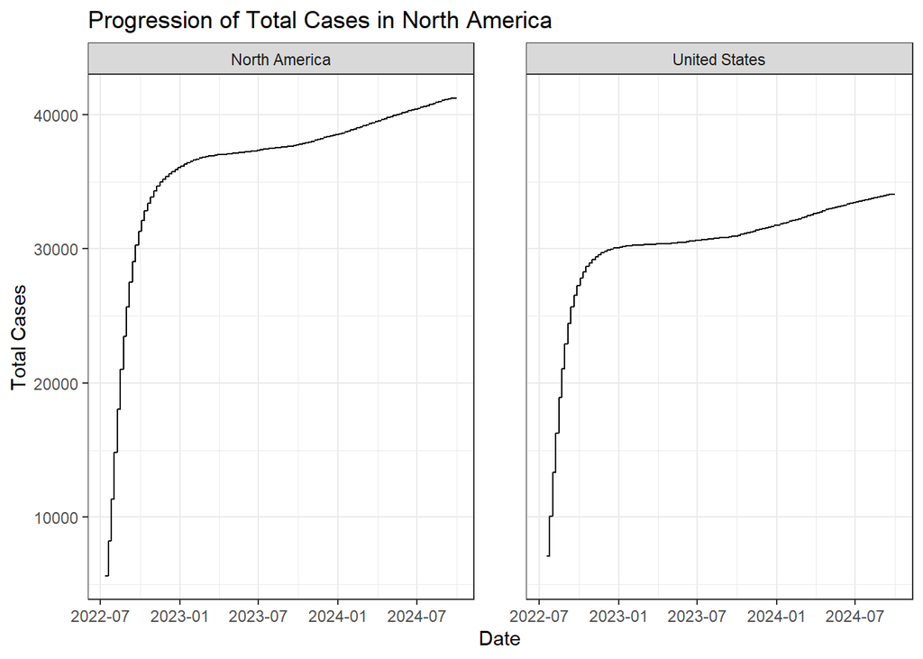

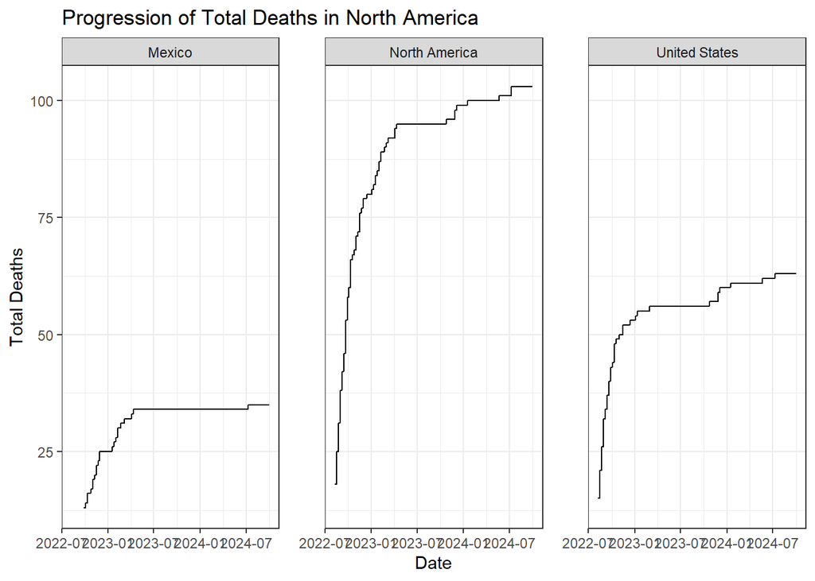

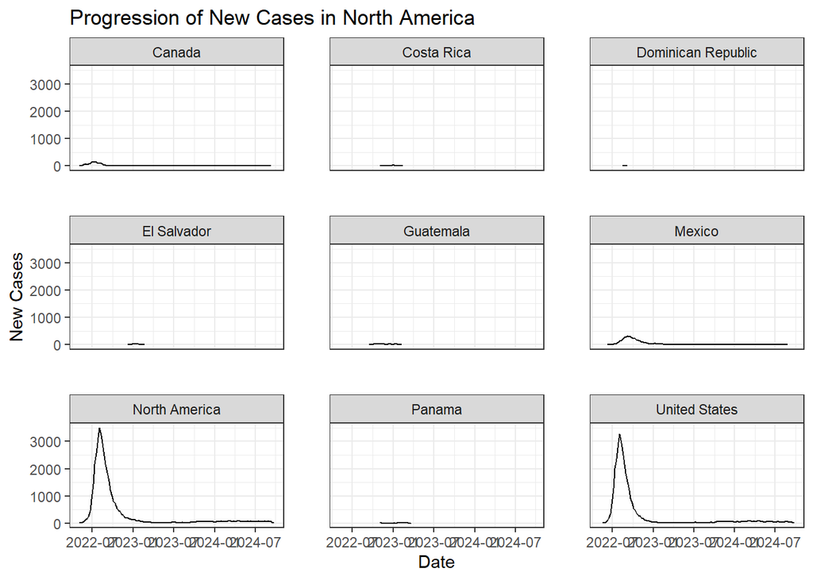

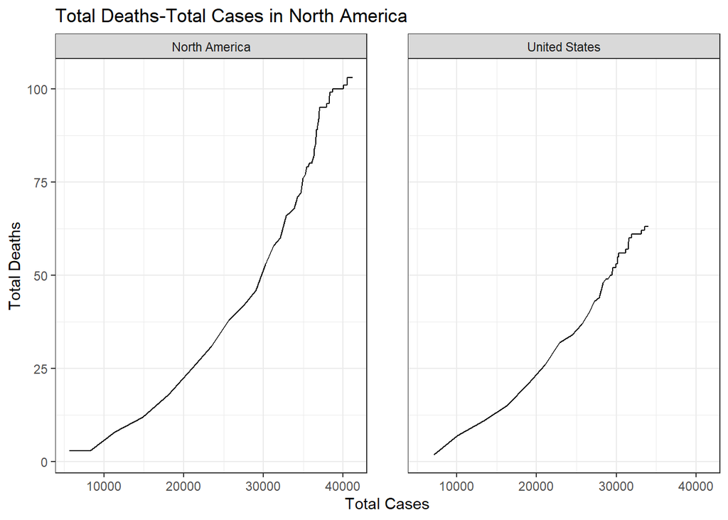

#### Summary

The United States look to be most affected Country in the North American Region.

### South_America

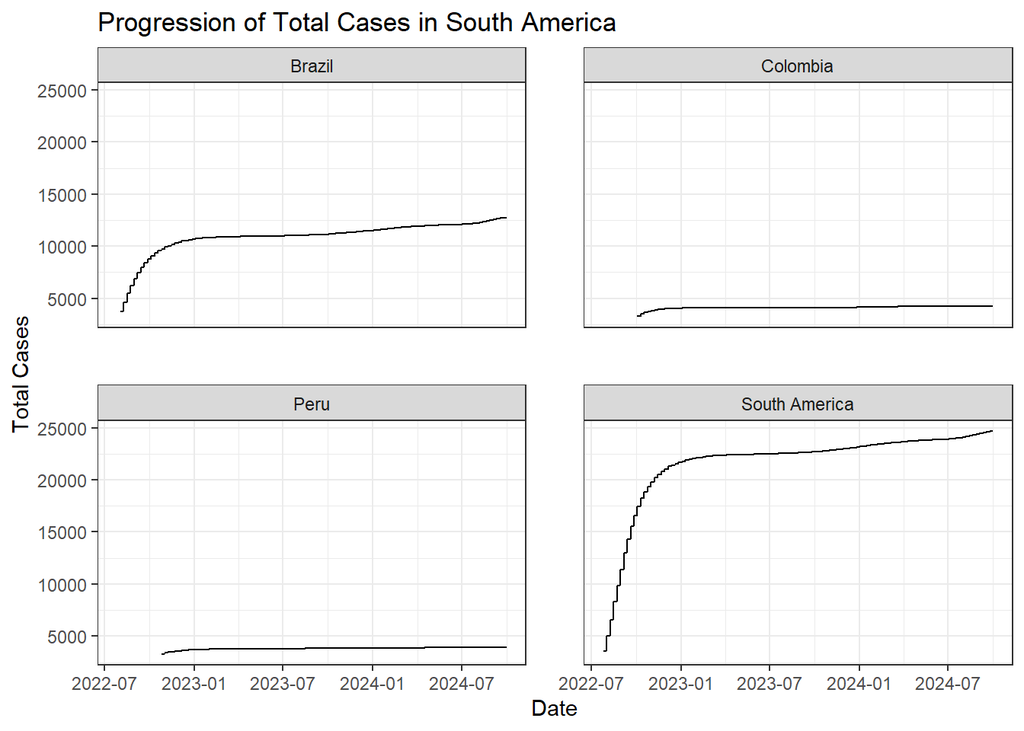

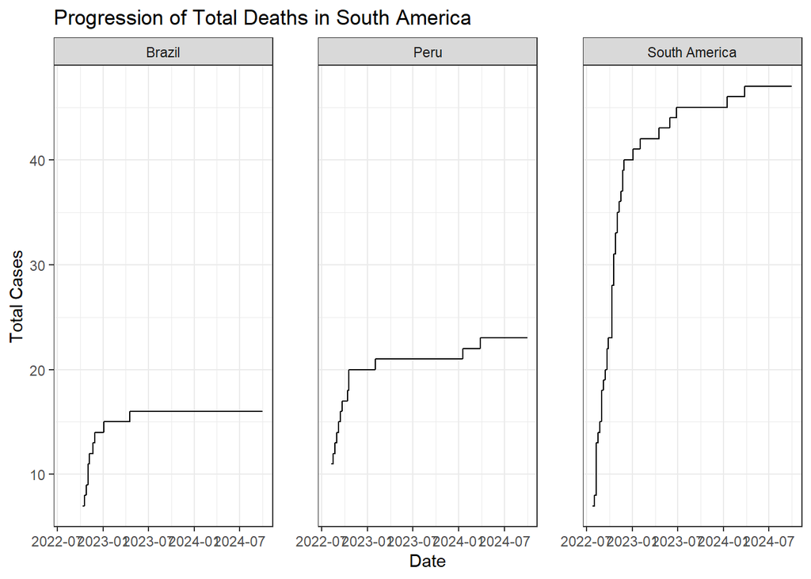

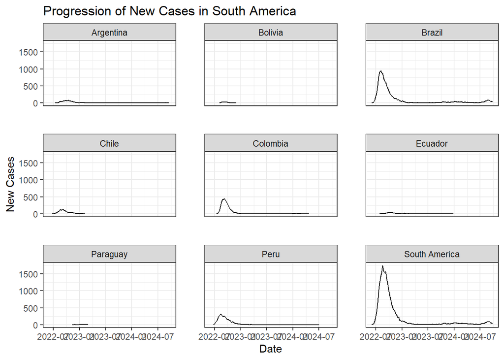

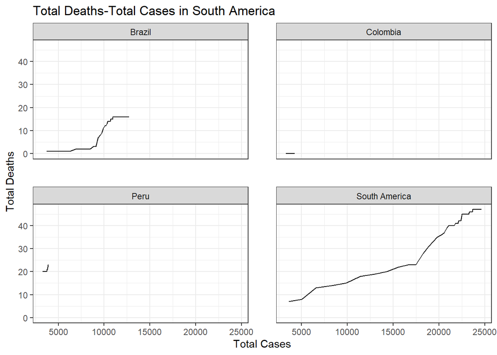

#### Summary

Brazil recorded the most amount of cases, but Peru recorded the most amount of death.

### Unspecified Region

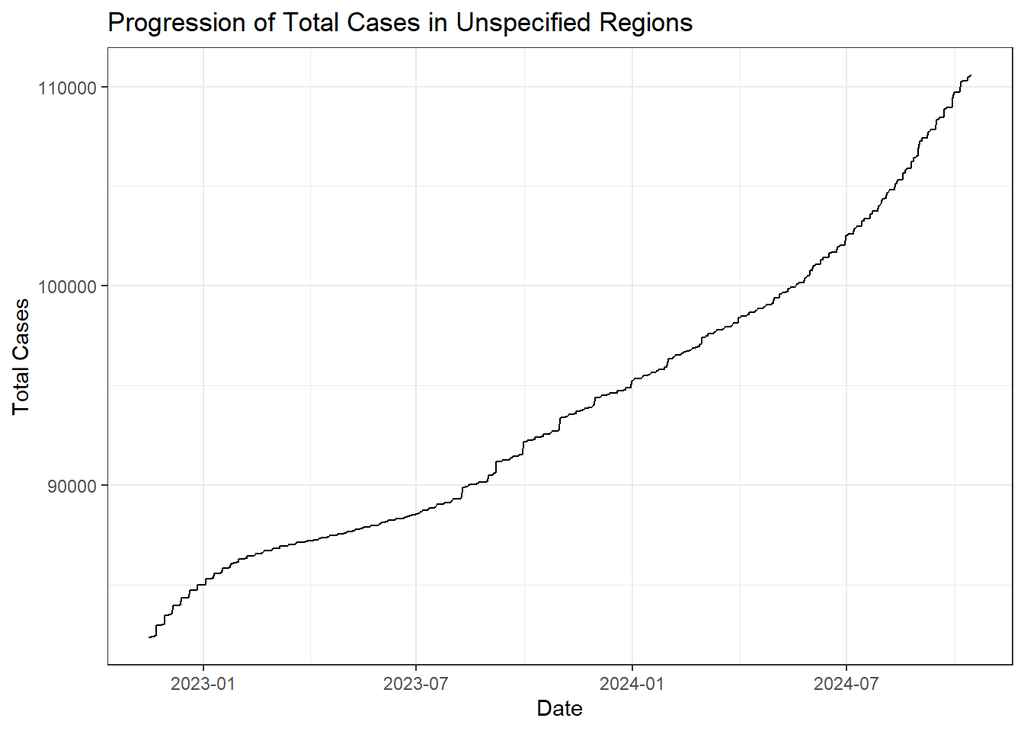

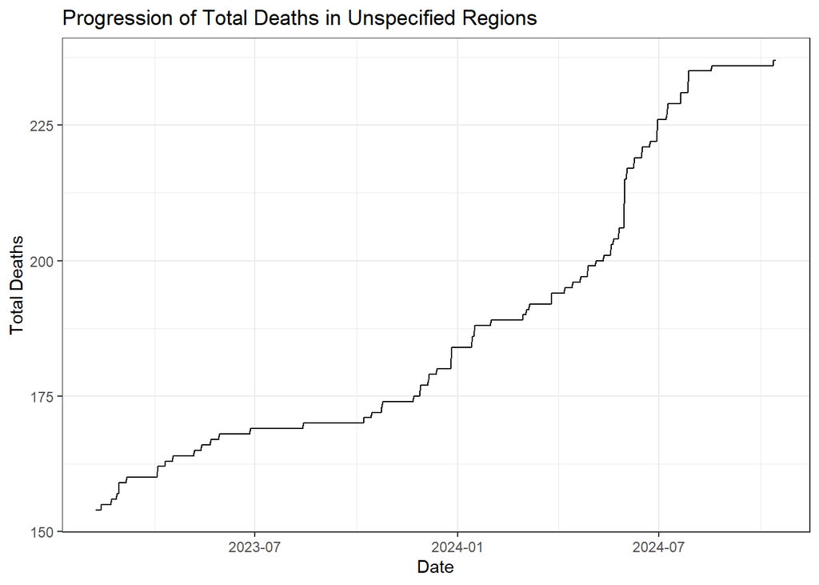

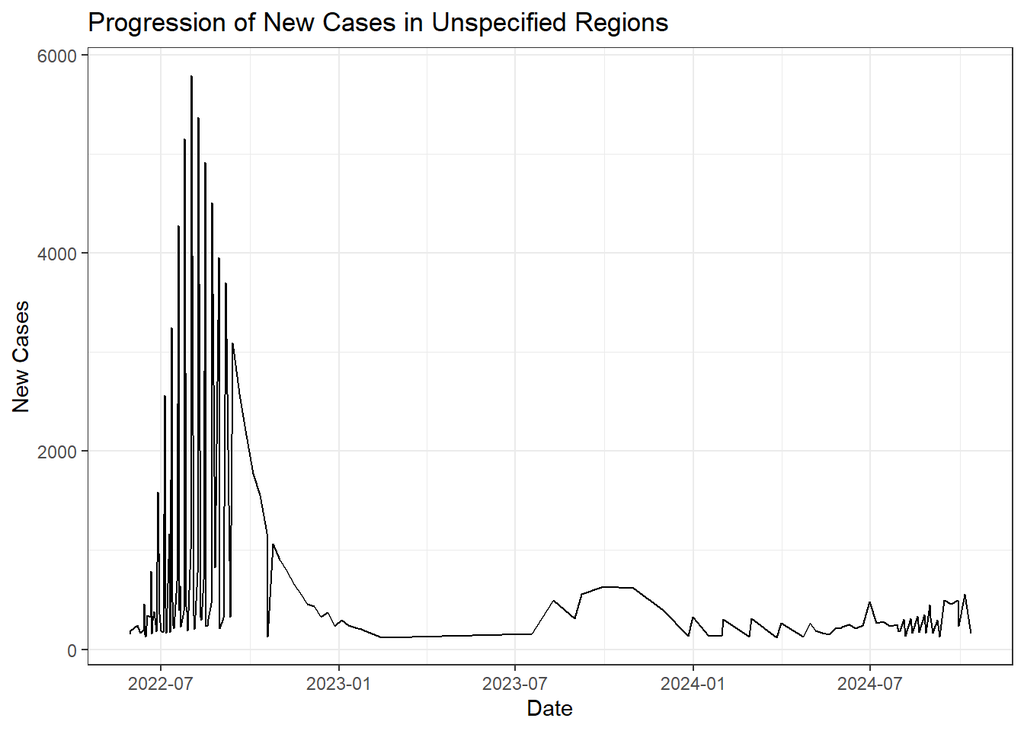

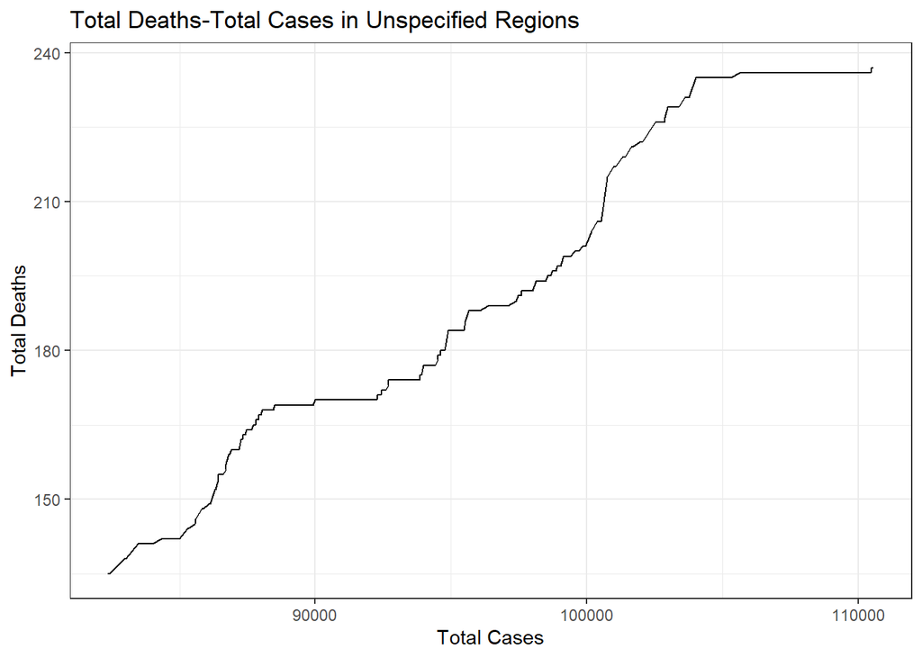

#### Summary

Highest amount of cases, deaths among all the regions.

## Findings

### North-America vs Africa

According to the graph of the grouped Statistics, excluding the unspecified region, there was a larger count of Average Total Death in the North American Region but this was not the region with the highest degree of Death rates, that would be Africa, this suggest that there may have been lack of proper facilities to handle cases of M-pox in that region leading to such a high Fatality rate in that region.

### Unspecified Region

The lack of proper data for the location causes a lot of hindrances when trying to understand this data as it has the largest recorded Average total number of cases and as well as Average total Deaths, this group however has one of the smallest Average Death Rate count indicating that despite the large number the cases, these cases where properly managed and extreme cases of death was prevented.

## Git-Hub Repository

https://github.com/Astro0re/Data/tree/main/Monkey%20_Pox